# Developing Data Projects Week 4 Project

Vanessa Drury  
August 3, 2020

## Summary

My shiny app is called “Create Your Own Confetti Cannon”. It uses basic plotting of randomized coordinates to create a “confetti blast”. Customizable features include:

- window of explosion
- number of confetti pieces
- color of confetti pieces
- shape of confetti pieces
- size of confetti pieces
- title of plot

## ui.R Code

The ui.R script features code for a sidebar with:

- numeric input window for pieces of confetti
- slider input for:
  - X axis boundaries
  - Y axis boundaries
- select input for:
  - confetti colors (6 options, up to 6 selections possible)
  - confetti shape (4 options, 1 selection possible)
  - confetti size (3 options, 1 selection possible)
  - title of plot (3 options, 1 selection possible)

## server.R Code

The server.R script takes input from ui.R to render the final plot.

- X and Y boundaries slider input determines the plot's `min/max X, min/max Y`
- color determines plot point `color` (randomized when more than 1 color is selected)
- shape determines plot point `pch`
- size determines plot point `cex`
- title determines plot label `main`

## [Shiny app](https://vedrury.shinyapps.io/DDPWeek4/)

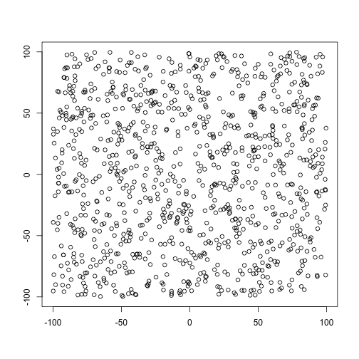

Here is the original plot the application was based on.

Follow the link in title to try the customized app.

The [ui.R script](https://github.com/vedrury/DDPWeek4/blob/master/DDPWeek4/ui.R) and server.R can be found at [this github repo](https://github.com/vedrury/DDPWeek4/tree/master/DDPWeek4).